# 540310809- Assignment-5002

SID:540310809

2025-05-25

All intermediate calculations are rounded to three decimal places unless otherwise stated.

## Question 1

Initialize data:

```r
test.A = c(5.90, 5.26, 2.97, 7.15, 10.06, 11.87, 1.94, 6.27, 6.81, 4.08,
8.13, 15.18, 8.82, 3.87, 5.23, 11.29, 7.92, 12.82, 7.20, 10.03)
test.B = c(6.07, 4.89, 2.92, 7.00, 9.99, 11.70, 1.94, 5.86, 6.95, 4.03, 7.76,
15.02, 9.08, 3.73, 4.88, 10.81, 8.05, 12.96, 7.10, 10.07)
```

### (a) Parameters & Hypotheses

Let $\mu_D$ be the mean difference in deceleration ($D = \text{test.A} - \text{test.B}$).  
Null hypothesis ($H_0$): $\mu_D = 0$ (no difference)  
Alternative hypothesis ($H_1$): $\mu_D > 0$ (new tire better)

### (b) Choice of Test

A paired t-test should be used. This is because:  
1. The measurements are paired (each vehicle is tested under both conditions), so we are interested in the mean of the differences.  
2. A two-sample t-test is not appropriate, as it assumes independent samples, which is not the case here.  
3. A z-test requires the population standard deviation to be known, but here we estimate it from the sample.  
4. A chi-squared test is used for categorical data, while our data are continuous.  
Therefore, a paired t-test is suitable, provided the differences are approximately normally distributed.

### (c) Graphical Summaries

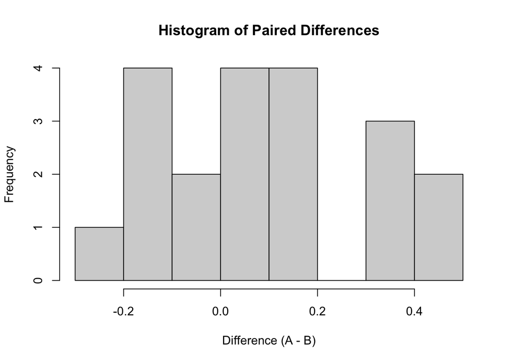

```r
diffs <- test.A - test.B
hist(diffs, main="Histogram of Paired Differences", xlab="Difference (A - B)")
```

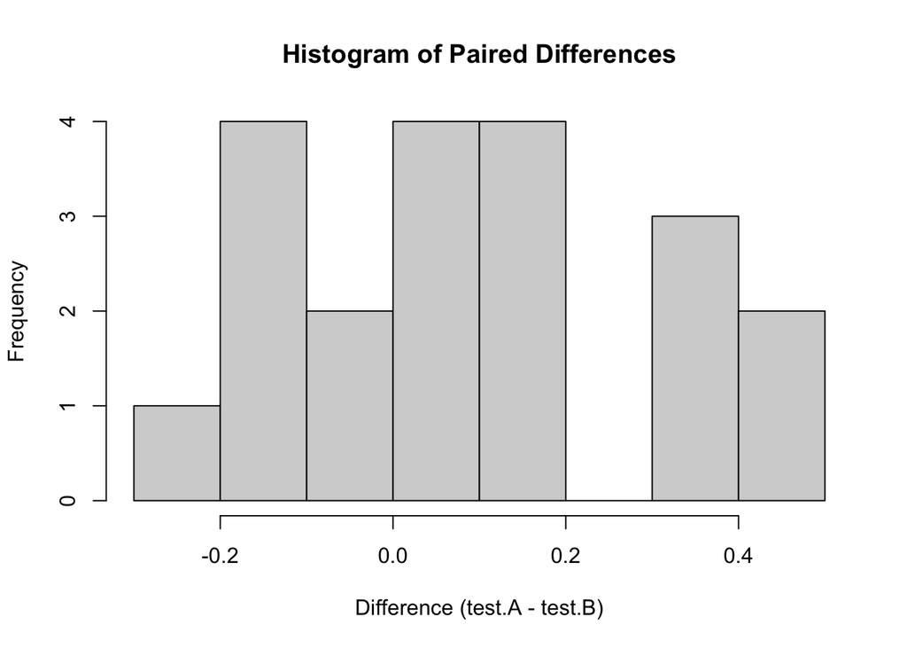

```r
# Histogram of the differences
hist(diffs, main = "Histogram of Paired Differences", xlab = "Difference (test.A - test.B)")
```

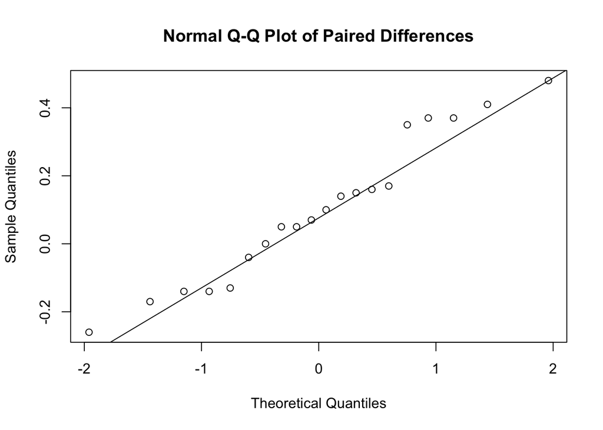

```r
# Normal Q-Q plot
qqnorm(diffs, main = "Normal Q-Q Plot of Paired Differences")
qqline(diffs)
```

### (d) Compute Test Statistic & P-value

The sample mean and standard deviation of the differences, the test statistic, and the p-value:

```r
n <- length(diffs)
mean_diff <- mean(diffs)
sd_diff <- sd(diffs)
se_diff <- sd_diff / sqrt(n)
t_stat <- mean_diff / se_diff
t_stat
```

```
## [1] 2.082483
```

The degrees of freedom are $n-1 = 19$.  
Under $H_0$, the test statistic follows a $t$-distribution with $n-1$ degrees of freedom.

One-sided P-value ($H_1: \mu_D > 0$):

```r
p_val <- 1 - pt(t_stat, df = n - 1)
p_val
```

```
## [1] 0.0255262
```

R’s built-in function:

```r
t.test(test.A, test.B, paired = TRUE, alternative = "greater")
```

```
##
##  Paired t-test
##
## data:  test.A and test.B
## t = 2.0825, df = 19, p-value = 0.02553
## alternative hypothesis: true mean difference is greater than 0
## 95 percent confidence interval:
##  0.01688288        Inf
## sample estimates:
## mean difference
##          0.0995
```

In this context, large positive values of the test statistic provide evidence against $H_0$ and in favor of $H_1$.

### (e) Conclusion

Using a significance level of $\alpha = 0.05$, the calculated P-value is 0.026.

Since the P-value (0.026) is less than 0.05, the null hypothesis is rejected.  
Therefore, there is sufficient evidence at the 5% significance level to conclude that the new tire provides significantly greater mean braking deceleration than the standard tire.

### (f) Perform a bootstrap simulation (with 10,000 repetitions) to simulate the test statistic, and plot the histogram. Does the histogram agree with the theoretical distribution?

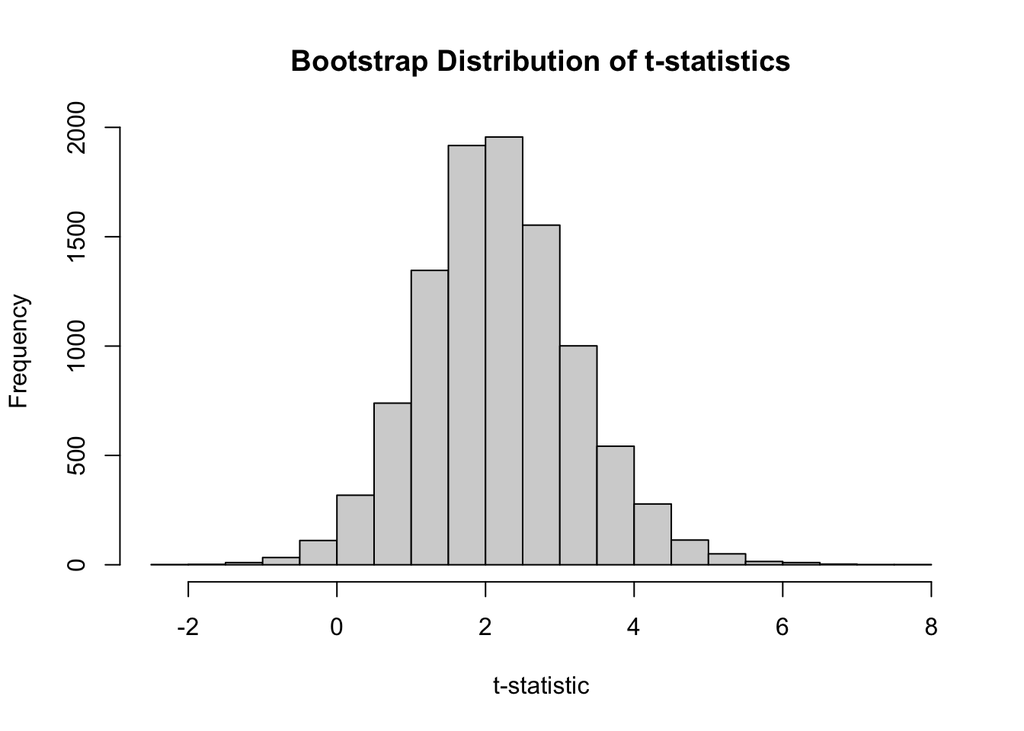

```r
set.seed(123)
B <- 10000
boot_t_stats <- replicate(B, {
  sample_diffs <- sample(diffs, replace = TRUE)
  mean(sample_diffs) / (sd(sample_diffs) / sqrt(n))
})
hist(boot_t_stats, breaks = 30, main = "Bootstrap Distribution of t-statistics", xlab = "t-statistic")
```

### (g) What is the P-value based on the simulated test statistics?

```r
boot_p_value <- mean(boot_t_stats >= t_stat)
boot_p_value
```

```
## [1] 0.5217
```

## Question 2

```r
group.A <- c(5.54, 4.41, 6.35, 5.04, 7.33, 6.47, 4.08, 6.00, 7.39, 5.53, 1.54, 6.16,
             4.23, 2.36, 5.09, 5.10, 5.33, 3.75, 6.49, 2.13, 5.44, 7.74, 3.80)
group.B <- c(4.31, 6.20, 5.25, 2.14, 3.26, 1.47, 2.24, 4.20, 3.56, 3.68, 7.02, 2.94,
             5.49, 3.37, 4.59, 3.05, 5.24)
```

### (a) State the null and alternative hypotheses to test whether two programs have the same effect on the student performance.

Let $\mu_A$ be the population mean performance of students in Group A (Online Tutoring) and $\mu_B$ for Group B (In-Person Tutoring).

Null hypothesis ($H_0$): $\mu_A = \mu_B$ (The two programs have the same effect on student performance.)  
Alternative hypothesis ($H_1$): $\mu_A \neq \mu_B$ (The two programs have different effects on student performance.)

### (b) Use appropriate graphical and numerical summaries to assess whether the necessary assumptions for applying the classical two-sample t-test are satisfied.

The following graphical and numerical summaries are used to assess the assumptions required for the classical two-sample t-test:

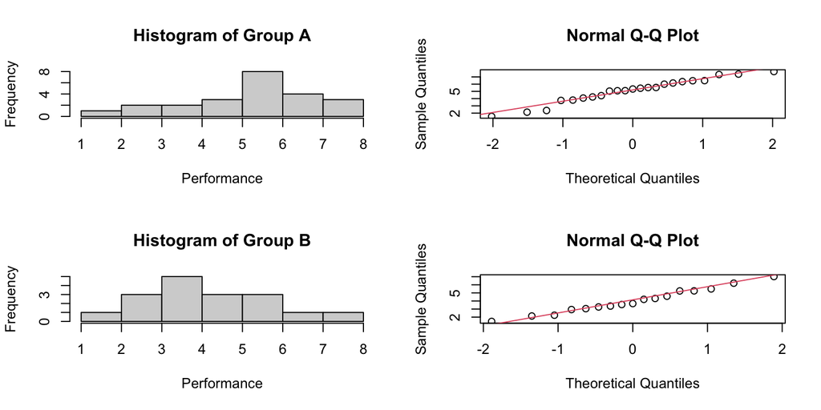

```r
par(mfrow=c(2,2))
hist(group.A, main="Histogram of Group A", xlab="Performance")
qqnorm(group.A); qqline(group.A, col=2)
hist(group.B, main="Histogram of Group B", xlab="Performance")
qqnorm(group.B); qqline(group.B, col=2)
```

```r
par(mfrow=c(1,1))
```

```r
mean.A <- mean(group.A)
mean.B <- mean(group.B)
sd.A <- sd(group.A)
sd.B <- sd(group.B)
n.A <- length(group.A)
n.B <- length(group.B)
mean.A; sd.A; n.A
```

```
## [1] 5.1
```

```
## [1] 1.64911
```

```
## [1] 23
```

```r
mean.B; sd.B; n.B
```

```
## [1] 4.000588
```

```
## [1] 1.499781
```

```
## [1] 17
```

Interpretation:

Normality can be visually assessed from the histograms and Q-Q plots. If the Q-Q plot points approximately follow the reference line and the histograms appear symmetric, the normality assumption is considered reasonable. A comparison of standard deviations provides information regarding the assumption of equal variances.

### (c) Formula and Calculation of the Classical Two-Sample t-Test Statistic

The test statistic for the classical two-sample t-test (assuming equal variances) is defined as follows:
$$t = \frac{\bar{X}_A - \bar{X}_B}{S_p \sqrt{1/n_A + 1/n_B}}$$
where
$$S_p = \sqrt{\frac{(n_A - 1) S_A^2 + (n_B - 1) S_B^2}{n_A + n_B - 2}}$$

Step-by-step calculation (values rounded to three decimal places):

```r
S_p <- sqrt(((n.A - 1)*sd.A^2 + (n.B - 1)*sd.B^2) / (n.A + n.B - 2))
S_p <- round(S_p, 3)
t_stat2 <- (mean.A - mean.B) / (S_p * sqrt(1/n.A + 1/n.B))
t_stat2 <- round(t_stat2, 3)
S_p
```

```
## [1] 1.588
```

```r
t_stat2
```

```
## [1] 2.165
```

### (d) Critical Region and Conclusion

At the 5% significance level, the two-sided critical values are $\pm t_{\alpha/2,,df}$, where $df = n_A + n_B - 2$:

```r
alpha <- 0.05
df2 <- n.A + n.B - 2
crit_val <- qt(1 - alpha/2, df2)
crit_val <- round(crit_val, 3)
crit_val
```

```
## [1] 2.024
```

The degrees of freedom for the test are $df = n_A + n_B - 2 = 38$.  
The two-sided critical value at the 5% significance level is 2.024·

Since the absolute value of the observed test statistic (2.165) exceeds the critical value (2.024), the null hypothesis is rejected at the 5% significance level.  
Therefore, there is sufficient evidence to conclude that the two tutoring programs have different effects on student performance.

### (e) Welch t-Test in R and Comparison

Welch’s t-test, which does not assume equal variances, is performed in R as follows:

```r
welch_out <- t.test(group.A, group.B, var.equal = FALSE)
welch_out
```

```
##
##  Welch Two Sample t-test
##
## data:  group.A and group.B
## t = 2.1964, df = 36.294, p-value = 0.03453
## alternative hypothesis: true difference in means is not equal to 0
## 95 percent confidence interval:
##  0.0845232 2.1143003
## sample estimates:
## mean of x mean of y
##  5.100000  4.000588
```

The P-value from the Welch t-test (0.03453) is also less than 0.05, which leads to the same conclusion as the classical two-sample t-test. Both tests indicate there is sufficient evidence to suggest that the two programs have different effects on student performance.

## Question 3

```r
# Observed frequency table (age group rows, device columns)
obs <- matrix(
  c(12, 6, 12,   # Under 18: Laptop, Desktop, Tablet
    14, 10, 6,   # 18–29
    16, 12, 12,  # 30–49
    8, 16, 6),   # 50+
  nrow = 4, byrow = TRUE)
colnames(obs) <- c("Laptop", "Desktop", "Tablet")
rownames(obs) <- c("Under 18", "18-29", "30-49", "50+")
obs
```

```
##          Laptop Desktop Tablet
## Under 18     12       6     12
## 18-29        14      10      6
## 30-49        16      12     12
## 50+           8      16      6
```

## (a) Null and Alternative Hypotheses

Null hypothesis ($H_0$): Device preference is independent of age group.  
Alternative hypothesis ($H_1$): Device preference is not independent of age group.

## (b) Expected Frequencies Table

The expected frequency for each cell, under the null hypothesis, is calculated as:
$$E_{ij} = \frac{\text{Row}_i\ \text{total} \times \text{Column}_j\
\text{total}}{\text{Grand total}}$$

```r
row_totals <- rowSums(obs)
col_totals <- colSums(obs)
grand_total <- sum(obs)
exp <- outer(row_totals, col_totals) / grand_total
exp <- round(exp, 3)
exp
```

```
##          Laptop Desktop Tablet
## Under 18 11.538  10.154  8.308
## 18-29    11.538  10.154  8.308
## 30-49    15.385  13.538 11.077
## 50+      11.538  10.154  8.308
```

## (c) Assumptions for the Chi-squared Test

The chi-squared test for independence requires that the following conditions are met: 1. Observations must be independent. 2. The expected frequency in each cell should be at least 5.

Based on the result of (b), All expected frequencies are greater than 5.  
Therefore, the assumptions required for the validity of the chi-squared test are satisfied.

## (d) Computation of the Test Statistic

The chi-squared test statistic is computed as:
$$\chi^2 = \sum \frac{(O_{ij} - E_{ij})^2}{E_{ij}}$$

```r
chi2 <- sum((obs - exp)^2 / exp)
chi2 <- round(chi2, 3)
chi2
```

```
## [1] 9.895
```

## (e) Critical Region and Conclusion

Degrees of freedom: $df = (\text{number of rows} - 1) \times (\text{number of columns} - 1) = (4-1) \times (3-1) = 6$

The critical value at the 5% significance level:

```r
alpha <- 0.05
df <- 6
critical_value <- qchisq(1 - alpha, df)
critical_value <- round(critical_value, 3)
critical_value
```

```
## [1] 12.592
```

Conclusion: Since the observed chi-squared test statistic ($\chi^2 = 9.895$) does not exceed the critical value ($12.592$) at the 5% significance level, the null hypothesis is not rejected. Therefore, there is insufficient evidence to conclude that device preference is associated with age group. This result suggests that device preference and age group are independent based on the observed data.